# Customer Life-Time Value

Ahmed, Arun, Sanjay- Group 7

12/6/2019

### 0. Problem Summary

(.) 1. Develop an **attrition model**, to predict whether a customer will cancel their subscription in the near future. Characterize your model performance. (.) 2. Develop a model for estimating the **ltv** of a customer. Characterize your model performance. (✓) 3. Develop a **customer segmentation** scheme. Include in this scheme the identification of sleeping customers, those that are no longer active but have not canceled their account.

#### About the dataset:

- id: A unique user identifier
- status: Subscription status:‘0’- new, ‘1’- open, ‘2’- cancelation event
- gender: User gender ‘M’- male ‘F’- female
- date: Date of in which user ‘id’ logged into the site
- pages: Number of pages visted by user ‘id’ on date ‘date’
- onsite: Number of minutes spent on site by user ‘id’ on date ‘date’
- entered: Flag indicating whether or not user entered the send order path on date ‘date’
- completed: Flag indicating whether the user completed the order (sent an eCard)
- holiday: Flag indicating whether at least one completed order included a holiday themed card

### 1. Exploratory Data Analysis

```
##   id status gender       date pages onsite entered completed holiday
## 1  1      0      M 10/31/2014     7      3       1         1       0
## 2  1      1      M  11/1/2014     6      8       0         0       0
## 3  1      1      M  11/2/2014     6     20       1         0       0
## 4  1      1      M 12/15/2014     1      1       0         0       0
## 5  1      1      M 12/19/2014     1      1       0         0       0
## 6  1      2      M 12/23/2014     0      0       0         0       0
```

```
##        id         status     gender          date                pages
##  2480   :   166   0: 10000   F:358716   Min.   :2011-01-01   Min.   : 0.000
##  1176   :   157   1:387518   M: 45119   1st Qu.:2012-06-29   1st Qu.: 3.000
##  8405   :   156   2:  6317              Median :2013-05-04   Median : 5.000
##  3390   :   153                         Mean   :2013-04-10   Mean   : 5.018
##  5450   :   152                         3rd Qu.:2014-01-26   3rd Qu.: 7.000
##  5973   :   151                         Max.   :2014-12-31   Max.   :10.000
##  (Other):402900
##      onsite        entered    completed  holiday
##  Min.   :  0.000   0: 88011   0:176577   0:311882
##  1st Qu.:  2.000   1:315824   1:227258   1: 91953
##  Median :  5.000
##  Mean   :  8.831
##  3rd Qu.: 11.000
##  Max.   :220.000
##
```

#### 1.1. Missing values

```
##        id    status    gender      date     pages    onsite   entered completed
##         0         0         0         0         0         0         0         0
##   holiday
##         0
```

**Observation:** There are no missing values in the data

#### 1.2. Extreme values

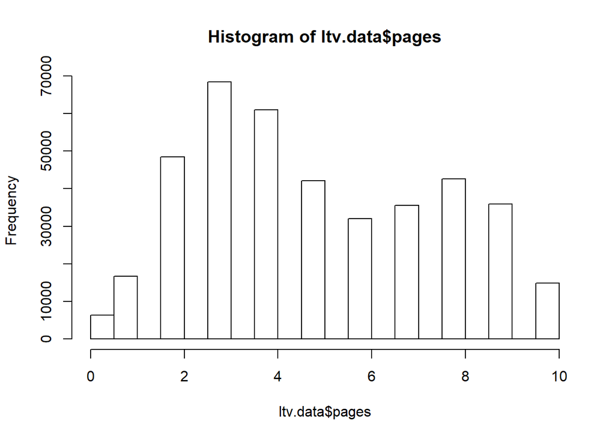

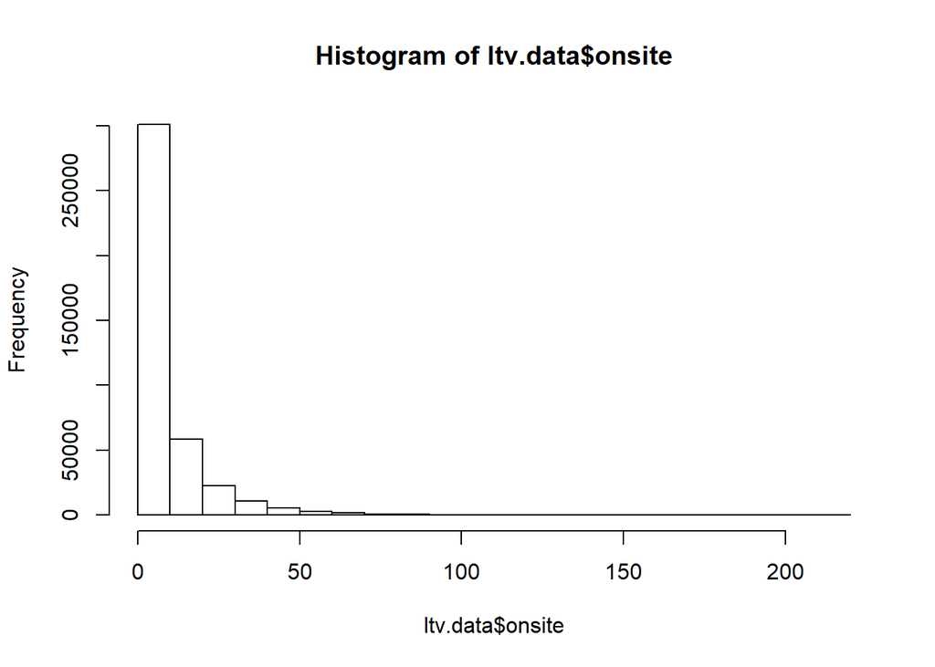

**Observation**: ‘Onsite’ has some extreme values

```
##   0%  10%  25%  50%  75%  90%  95%  99% 100%
##    0    1    2    5   11   22   32   57  220
```

**Action:** Cap observations where user has spent more than 60 minutes on the website to 60 minutes

#### 1.3. Cap obervations where user spent more then 60 minutes to 60 minutes

```
##        id         status     gender          date                pages
##  2480   :   166   0: 10000   F:358716   Min.   :2011-01-01   Min.   : 0.000
##  1176   :   157   1:387518   M: 45119   1st Qu.:2012-06-29   1st Qu.: 3.000
##  8405   :   156   2:  6317              Median :2013-05-04   Median : 5.000
##  3390   :   153                         Mean   :2013-04-10   Mean   : 5.018
##  5450   :   152                         3rd Qu.:2014-01-26   3rd Qu.: 7.000
##  5973   :   151                         Max.   :2014-12-31   Max.   :10.000
##  (Other):402900
##      onsite       entered    completed  holiday
##  Min.   : 0.000   0: 88011   0:176577   0:311882
##  1st Qu.: 2.000   1:315824   1:227258   1: 91953
##  Median : 5.000
##  Mean   : 8.686
##  3rd Qu.:11.000
##  Max.   :60.000
##
```

#### 1.4. Gender and Tenure

```
## [1] "Number of users: 10000"
```

```
## [1] "Users by gender:"
```

```
##   gender count
## 1      F  7924
## 2      M  2076
```

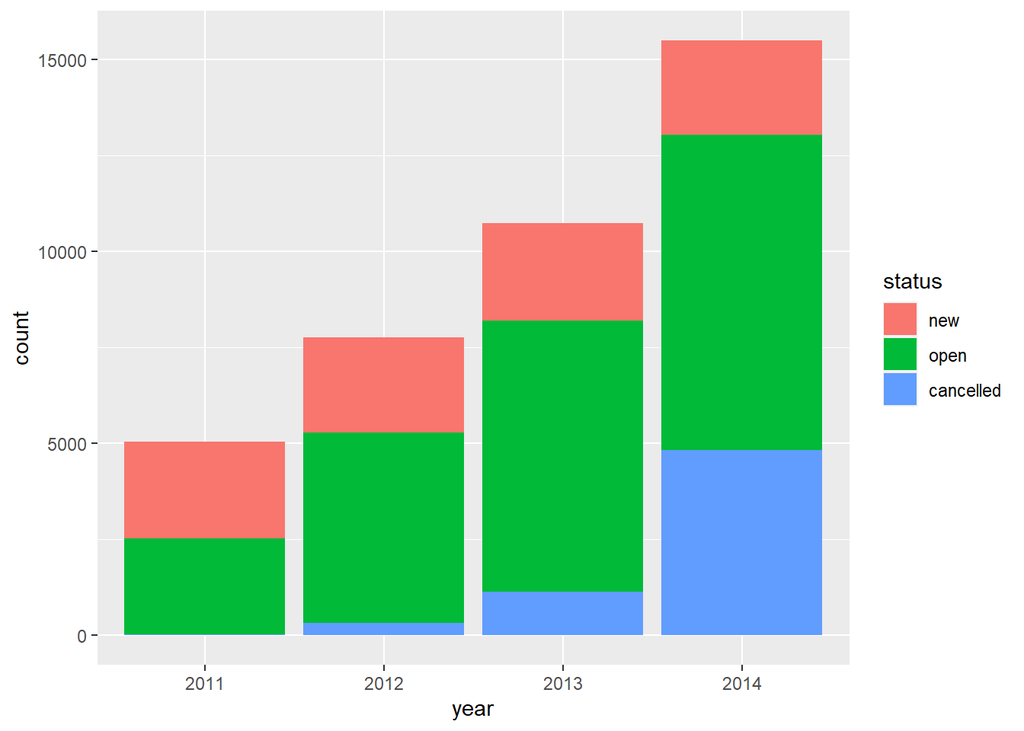

# 2. Predicting if the customer will cancel their subscription

Multiple researches have shown that it could be more expensive to retain a customer than to create a new customer. Hence, it is of high interest to be able to predict customers who mightleave the business in near future and adopt some strategies to prevent such customers could be of high business value.

## 2.1 Feature Engineering

While carying out EDA, we noticed that we are intersted in the variable `status` which tracks the customer status i.e. if the customer joined recently `0`, or if he is still ther `1` or if he left `2`. In order to facilitate our analysis we will create a new variable, `is.churn` with values `1` if the customer has churned (attrition) else `0`. The two level variable will give us mor eflexibility in terms of model such as Logistic Regression without compromising on the information quality.

Further, to assist in our analysis we will create new variables that will capture the existing information in a better way.

1. `total.time` = how much time in total the customer spent
2. `avg.time` = average time spent per customer
3. `total.pg` = total number of pages visited by customer
4. `avg.pg` = average number of pages visited by customer
5. `avg.entered` = average path entered
6. `avg.completed` = average path completed
7. `avg,intertime` = average intertime spent by a customer. Intertime being the duration between two consecutive vists by the customer
8. `last.seen` = the last seen for the customer relative to `31-12-2014`
9. `tenure` = total time for which customer remained with us as a customer.

## 2.2 Checking for correlation between the available parameters

We started by analysing the corelation matrix for our features and realised that 4 out of 11 features were highly correlated. Since we were measuring total and average for the same paramters it makes sense that these were highly correlates.

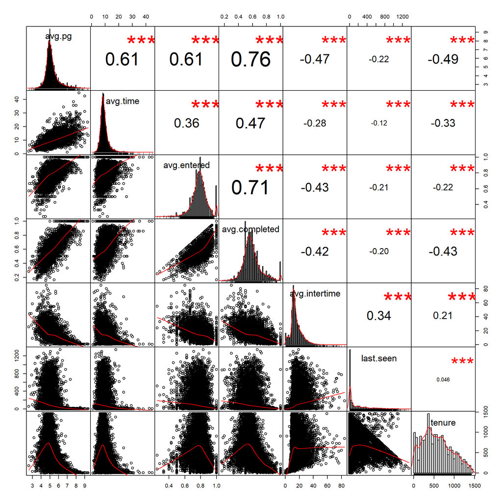

We notice that even though we have some highly corelated variable such as avg.entered and avg.completed. We would expect that still we would use the information since its less than `0.80`. Also, we see some outliers in the distribution for last seen. These would be users which are dormant for long time or left pretty early in our case. we would move forward after replacing these with more optimal values.

## 3. Selecting the best Attrition Model

### 3.1. Tree model

First, we tried a Tree model to see how we performed in our data classifiation

```
## Confusion Matrix and Statistics
##
##           Reference
## Prediction   No  Yes
##        No   591  486
##        Yes  514 1409
##
##                Accuracy : 0.6667
##                  95% CI : (0.6495, 0.6835)
##     No Information Rate : 0.6317
##     P-Value [Acc > NIR] : 3.419e-05
##
##                   Kappa : 0.2799
##
##  Mcnemar's Test P-Value : 0.3932
##
##             Sensitivity : 0.5348
##             Specificity : 0.7435
##          Pos Pred Value : 0.5487
##          Neg Pred Value : 0.7327
##              Prevalence : 0.3683
##          Detection Rate : 0.1970
##    Detection Prevalence : 0.3590
##       Balanced Accuracy : 0.6392
##
##        'Positive' Class : No
##
```

> The tree classification gives us a missclassification rate of = 33.3333333 % in our data set if we were to assign all the customers to `is.churn` = 1 we would have achieved the misclassification rate of 36.83%. SO, we have improved a little over that. However, we wish to see if we can do better.

### 3.2 logistic model

Next, we tried logistic model since we have only two classificantion groups.

```
##
## Call:
## glm(formula = is.churn ~ . - id, family = "binomial", data = final.data,
##     subset = train)
##
## Deviance Residuals:
##        Min          1Q      Median          3Q         Max
## -2.713e-03  -2.000e-08   2.000e-08   2.000e-08   2.617e-03
##
## Coefficients:
##                   Estimate Std. Error z value Pr(>|z|)
## (Intercept)     -8.620e+00  6.787e+02  -0.013    0.990
## total.pg        -1.605e-02  4.611e+00  -0.003    0.997
## avg.pg           1.472e-01  1.275e+02   0.001    0.999
## total.time      -4.610e-03  9.640e-01  -0.005    0.996
## avg.time         3.897e-02  1.756e+01   0.002    0.998
## total.entered    3.217e-02  3.049e+01   0.001    0.999
## avg.entered     -3.894e+00  1.050e+03  -0.004    0.997
## total.completed  1.687e-01  3.293e+01   0.005    0.996
## avg.completed   -5.473e+00  1.075e+03  -0.005    0.996
## avg.intertime    1.200e-02  1.646e+01   0.001    0.999
## last.seen        2.780e+01  1.019e+02   0.273    0.785
## diff            -3.007e+01  2.392e+02  -0.126    0.900
## tenure          -9.094e-04  5.270e-01  -0.002    0.999
## genderM         -5.618e-01  1.865e+02  -0.003    0.998
##
## (Dispersion parameter for binomial family taken to be 1)
##
##     Null deviance: 9.2286e+03  on 6999  degrees of freedom
## Residual deviance: 3.0560e-04  on 6986  degrees of freedom
## AIC: 28
##
## Number of Fisher Scoring iterations: 25
```

```
##          attrition.test.actual
## tree.pred   No  Yes
##       No   398  679
##       Yes  692 1231
```

```
## Confusion Matrix and Statistics
##
##           Reference
## Prediction   No  Yes
##        No   398  679
##        Yes  692 1231
##
##                Accuracy : 0.543
##                  95% CI : (0.525, 0.5609)
##     No Information Rate : 0.6367
##     P-Value [Acc > NIR] : 1.0000
##
##                   Kappa : 0.0097
##
##  Mcnemar's Test P-Value : 0.7459
##
##             Sensitivity : 0.3651
##             Specificity : 0.6445
##          Pos Pred Value : 0.3695
##          Neg Pred Value : 0.6401
##              Prevalence : 0.3633
##          Detection Rate : 0.1327
##    Detection Prevalence : 0.3590
##       Balanced Accuracy : 0.5048
##
##        'Positive' Class : No
##
```

### 3.3 Randomforest

In our first model, we used only a single tree and our results were ok. In this model we will use the available data sets to build random forest. or to fit multiple trees

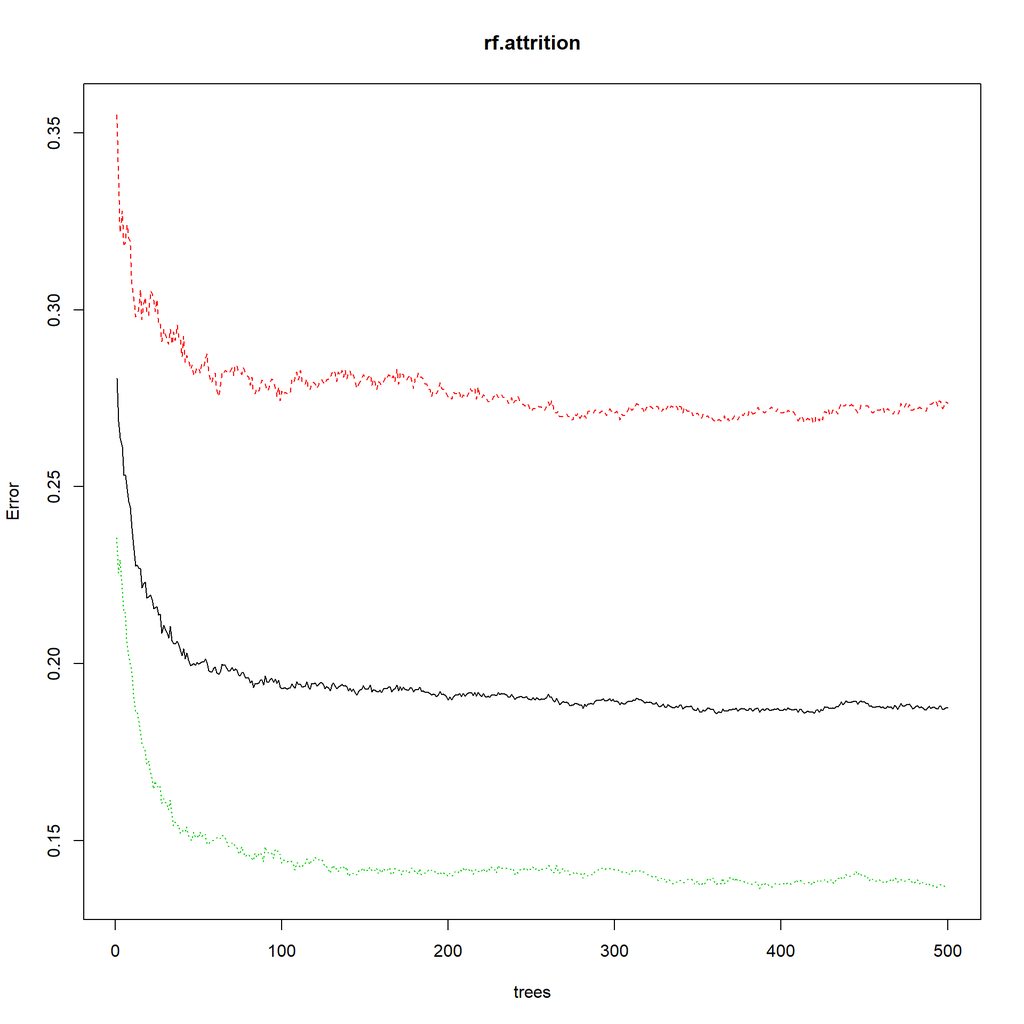

```
##        attrition.test.actual
## rf.pred   No  Yes
##     No   812  256
##     Yes  287 1645
```

```
## Confusion Matrix and Statistics
##
##           Reference
## Prediction   No  Yes
##        No   812  256
##        Yes  287 1645
##
##                Accuracy : 0.819
##                  95% CI : (0.8047, 0.8326)
##     No Information Rate : 0.6337
##     P-Value [Acc > NIR] : <2e-16
##
##                   Kappa : 0.6078
##
##  Mcnemar's Test P-Value : 0.1979
##
##             Sensitivity : 0.7389
##             Specificity : 0.8653
##          Pos Pred Value : 0.7603
##          Neg Pred Value : 0.8514
##              Prevalence : 0.3663
##          Detection Rate : 0.2707
##    Detection Prevalence : 0.3560
##       Balanced Accuracy : 0.8021
##
##        'Positive' Class : No
##
```

> The Random Forest model works real well and gives the missclassification rate of 18.1 %

Hence, we would go ahead with the final random forest model `rf.attrition`

To determine which are the features which impact whether the customer would churn or not, lets build `varImpPlot`.

Following figure gives the relative importance of variables in the model.

### 3.3.1 Variable Importance Plot

|  | No | Yes | MeanDecreaseAccuracy | MeanDecreaseGini |
| --- | --- | --- | --- | --- |
|  | Min. : -1.919 | Min. : 10.73 | Min. : 9.766 | Min. : 13.24 |
|  | 1st Qu.: 7.361 | 1st Qu.: 22.58 | 1st Qu.: 23.661 | 1st Qu.: 266.22 |
|  | Median : 23.345 | Median : 39.10 | Median : 52.911 | Median : 376.66 |
|  | Mean : 34.389 | Mean : 57.87 | Mean : 68.704 | Mean : 407.14 |
|  | 3rd Qu.: 43.455 | 3rd Qu.: 66.34 | 3rd Qu.: 76.754 | 3rd Qu.: 416.23 |
|  | Max. :123.894 | Max. :183.95 | Max. :220.980 | Max. :1093.95 |

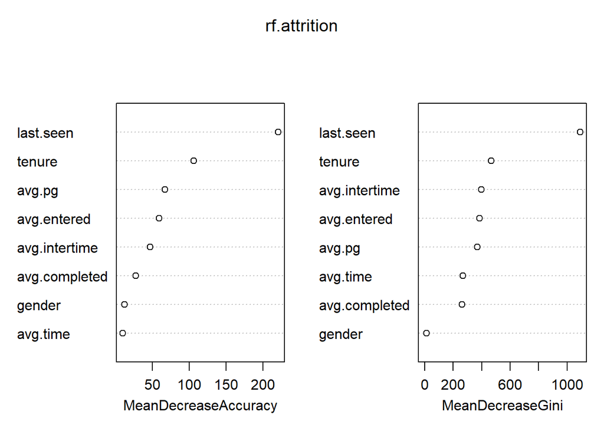

The variables `Last Seen` and `tenure` are the most important features for our model. Even though they do not tell us how are these related to our model.

We would like to use model to track these two variables and inform decision making.

# 3. Estimating ltv model

Customer ltv is equal to number of months between customer subscribing and cancelling their subscription

We used a regression model to estimate number of months

First we calculated lifetime value for each customer in our dataset and summary variables for their interactions

Assumptions made: fractions of months are billed as full month & customers with unknown cancellation date are assumed to cancel on “12/31/2014”

## 3.1 Variables and significant coeffiecients

Variables created to help estimate life-time value:

1. `num_activities` = number of times customer logged in
2. `avg_onsite` = average time spent by customer onsite
3. `male` = dummy variable for gender where 1 indicated customer is male
4. `avg_time_between_activity` = average time between consecutive activites by customer
5. `avg_pages` = average number of pages each time customer enters
6. `percent_completed` = percentage of interactions where customer completes card
7. `num_enter_not_complete` = number of times customer starts creating card but does not complete
8. `ratio_completed_holiday` = ration of completed cards that are holiday cards
9. `ltv` = total time for which customer remained with us as a customer

We ran linear regression on estimating ltv using all other variables and found the bewlo variables to have statistically significant coefficients

```
## [1] "male"                    "num_activities"
## [3] "avg_pages"               "percent_completed"
## [5] "num_enter_not_complete"  "ratio_completed_holiday"
```

## 3.2 Predictor selection

To choose variables to include in our final model we compared different model sizes on their R-squared, AIC score, BIC score on subsets selected using forward step-wise selection, we also compared average MSE for 50 runs of validation set approach per subset

We produced the plots below to help giude our decision

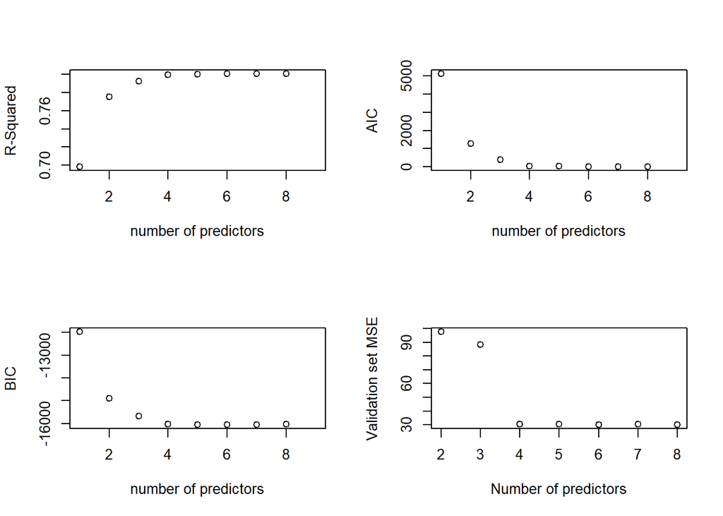

By observing the plts above we can see that there is no significant improvement on any of our score past four variables, to keep model as simple as possible we chose that our final will have four predicttors with coeffiecients displayed below

## 3.3 Final Model

Ou final model to predict customer lifetime value includes the variables below with their corresponding coeffiecients

```r
ltv.final.model <- glm(ltv ~ male + num_activities + avg_pages + ratio_completed_holiday, data = my_data_summary)


kable(coef(ltv.final.model))
```

|  | x |
| --- | --- |
| (Intercept) | 10.3323492 |
| male | 3.0497100 |
| num_activities | 0.3046944 |
| avg_pages | -1.8391173 |
| ratio_completed_holiday | 18.6271861 |

### Findings

“male” Keeping everyhing constant being of gender male is associated with staying a customer an average of 3 months (eqiuvilant to 3$ value)  
“num_activities” For each login customer does is associated with average 0.3$ more value  
“avg_pages” For each page in average that customer uses on site it is associated with an average of 1.8$ decrease in expected life-time value “ratio_completed_holiday” We found that a higher ratio of holiday card compared to total cards completed is associated with increased life-time value

# 4. Customer Segmentation

```r
# Import libraries
library(plyr)
library(ggplot2)
library(dplyr)
library(reshape2)
library(cluster)
library(factoextra)
```

```r
ltv.data <- ltv.data %>% mutate_at(vars(id, status, gender, entered, completed, holiday), funs(as.factor(.)))
ltv.data$date <- as.Date(ltv.data$date, '%m/%d/%Y')
summary(ltv.data)
```

```
##        id         status     gender          date                pages
##  2480   :   166   0: 10000   F:358716   Min.   :2011-01-01   Min.   : 0.000
##  1176   :   157   1:387518   M: 45119   1st Qu.:2012-06-29   1st Qu.: 3.000
##  8405   :   156   2:  6317              Median :2013-05-04   Median : 5.000
##  3390   :   153                         Mean   :2013-04-10   Mean   : 5.018
##  5450   :   152                         3rd Qu.:2014-01-26   3rd Qu.: 7.000
##  5973   :   151                         Max.   :2014-12-31   Max.   :10.000
##  (Other):402900
##      onsite        entered    completed  holiday
##  Min.   :  0.000   0: 88011   0:176577   0:311882
##  1st Qu.:  2.000   1:315824   1:227258   1: 91953
##  Median :  5.000
##  Mean   :  8.831
##  3rd Qu.: 11.000
##  Max.   :220.000
##
```

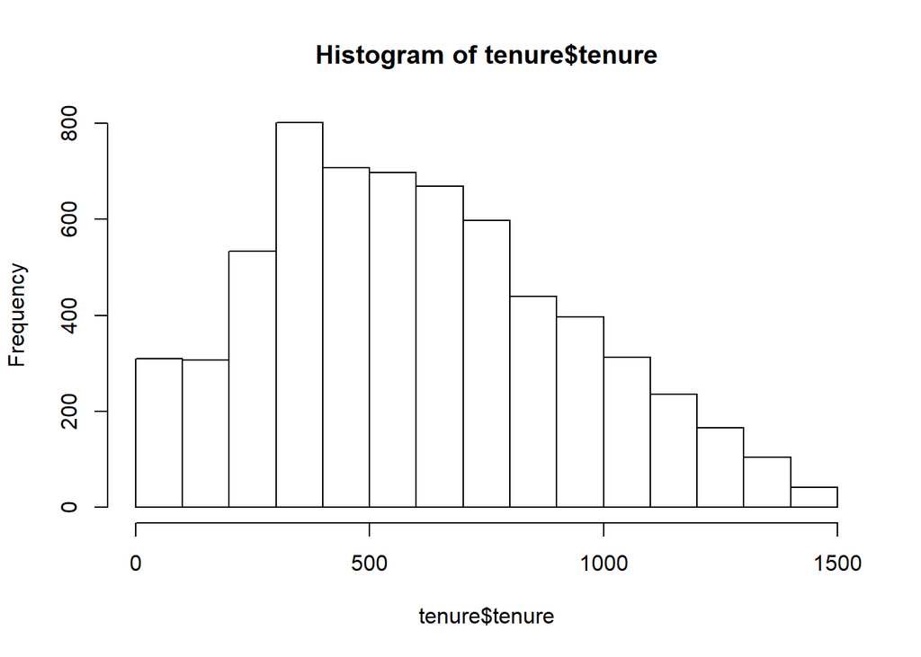

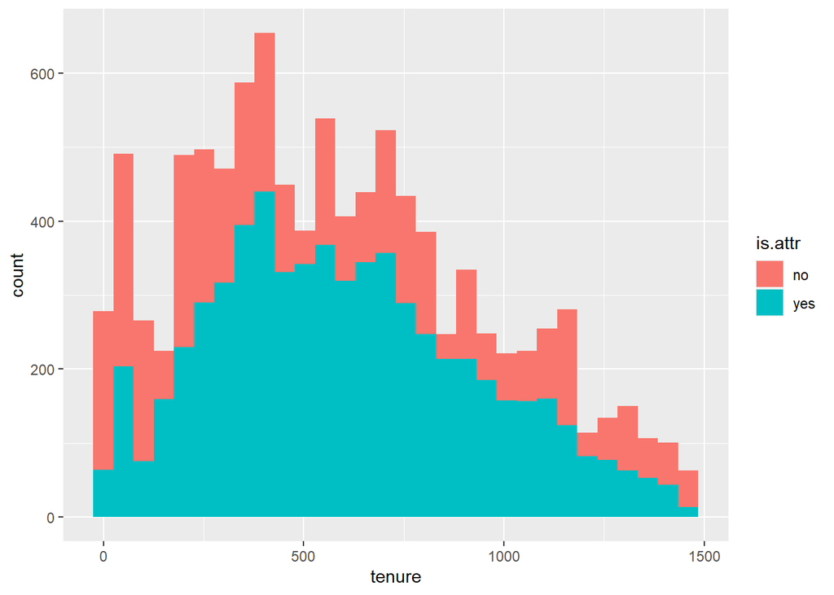

```
##    Min. 1st Qu.  Median    Mean 3rd Qu.    Max.
##       0     312     545     586     826    1460
```

```
## $no
##    Min. 1st Qu.  Median    Mean 3rd Qu.    Max.
##     1.0   199.0   443.0   553.7   853.5  1460.0
##
## $yes
##    Min. 1st Qu.  Median    Mean 3rd Qu.    Max.
##     0.0   360.0   569.0   604.8   822.0  1457.0
```

## 4.1 Feature engineering

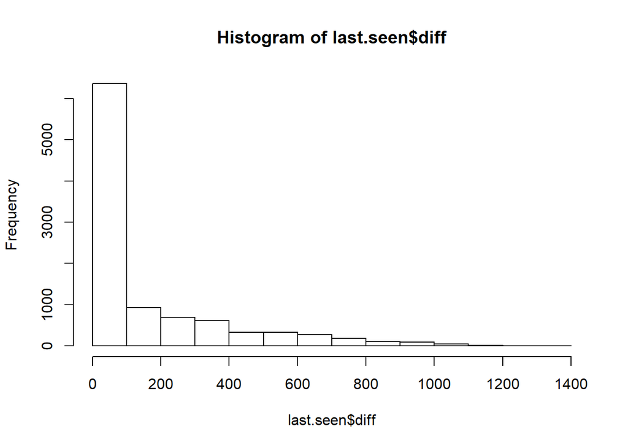

```
##        id       last.seen.days      last.seen             num.freq
##  3      :   1   Min.   :   0.00   Min.   :2011-12-23   Min.   :  0.0
##  4      :   1   1st Qu.:   7.00   1st Qu.:2014-12-17   1st Qu.: 14.0
##  6      :   1   Median :  10.00   Median :2014-12-21   Median : 29.0
##  7      :   1   Mean   :  43.37   Mean   :2014-11-17   Mean   : 40.3
##  10     :   1   3rd Qu.:  14.00   3rd Qu.:2014-12-24   3rd Qu.: 59.0
##  11     :   1   Max.   :1104.00   Max.   :2014-12-31   Max.   :165.0
##  (Other):3677
##     min.freq         max.freq        q1.freq          q3.freq
##  Min.   : 1.000   Min.   :  1.0   Min.   : 1.000   Min.   :  1.0
##  1st Qu.: 1.000   1st Qu.: 40.0   1st Qu.: 1.000   1st Qu.: 12.0
##  Median : 1.000   Median : 60.0   Median : 2.000   Median : 15.0
##  Mean   : 1.052   Mean   : 72.9   Mean   : 2.535   Mean   : 16.7
##  3rd Qu.: 1.000   3rd Qu.: 91.0   3rd Qu.: 3.000   3rd Qu.: 20.0
##  Max.   :57.000   Max.   :657.0   Max.   :83.000   Max.   :168.0
##  NA's   :2        NA's   :2       NA's   :2        NA's   :2
##     avg.freq      perctentile.last.seen     tenure
##  Min.   :  1.00   Min.   :0.0000        Min.   :   1.0
##  1st Qu.:  9.00   1st Qu.:0.5054        1st Qu.: 199.0
##  Median : 11.00   Median :0.6615        Median : 443.0
##  Mean   : 12.63   Mean   :0.6479        Mean   : 553.7
##  3rd Qu.: 15.00   3rd Qu.:0.8667        3rd Qu.: 853.5
##  Max.   :114.00   Max.   :1.0000        Max.   :1460.0
##  NA's   :2        NA's   :2
```

## 4.2. Clustering

### 4.2.1 Hierarchical Clustering

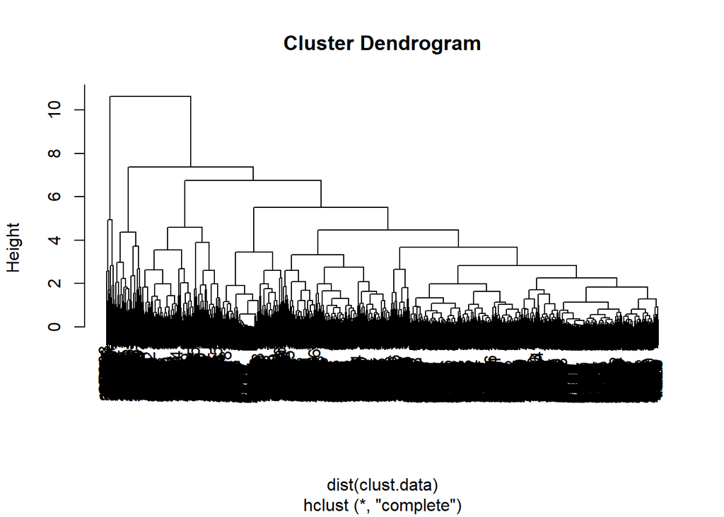

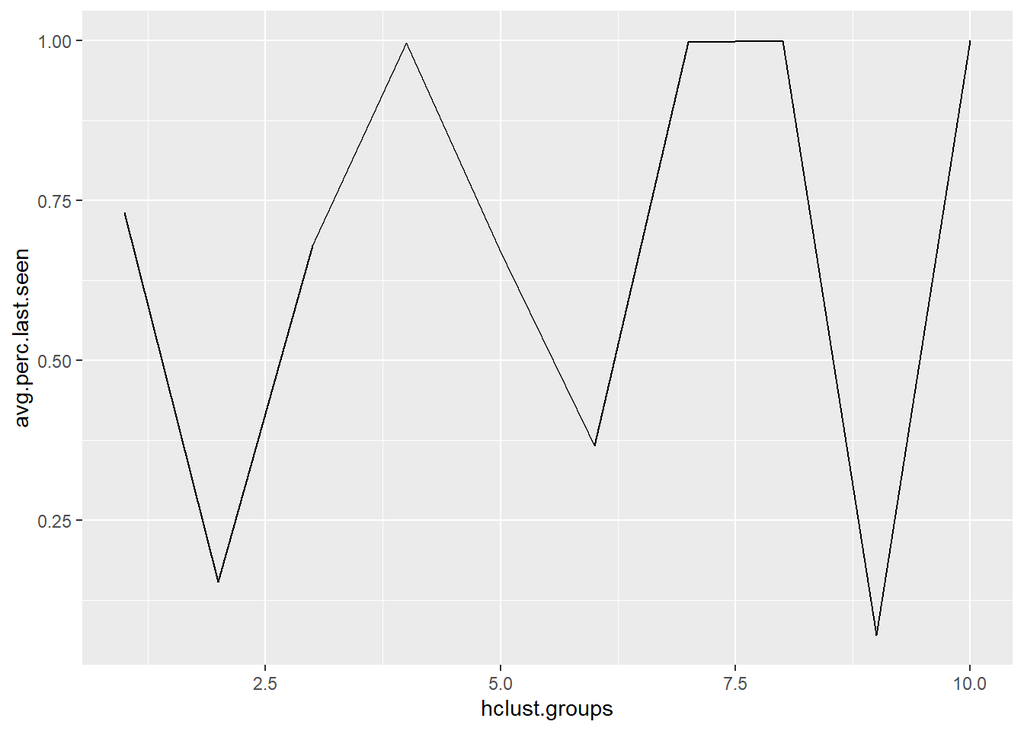

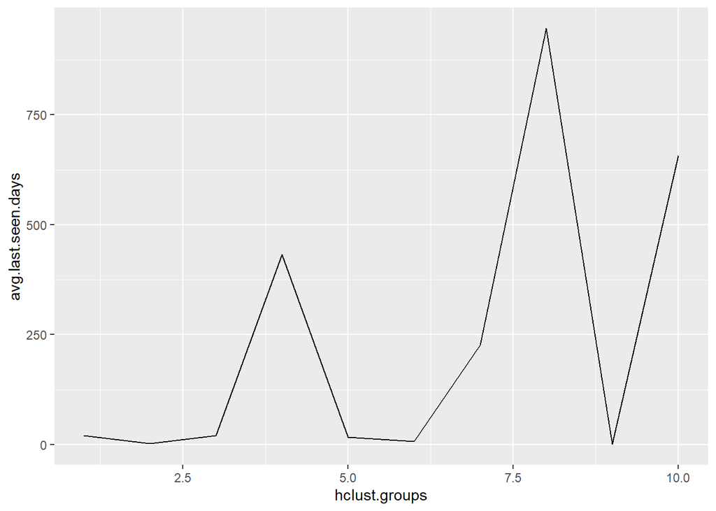

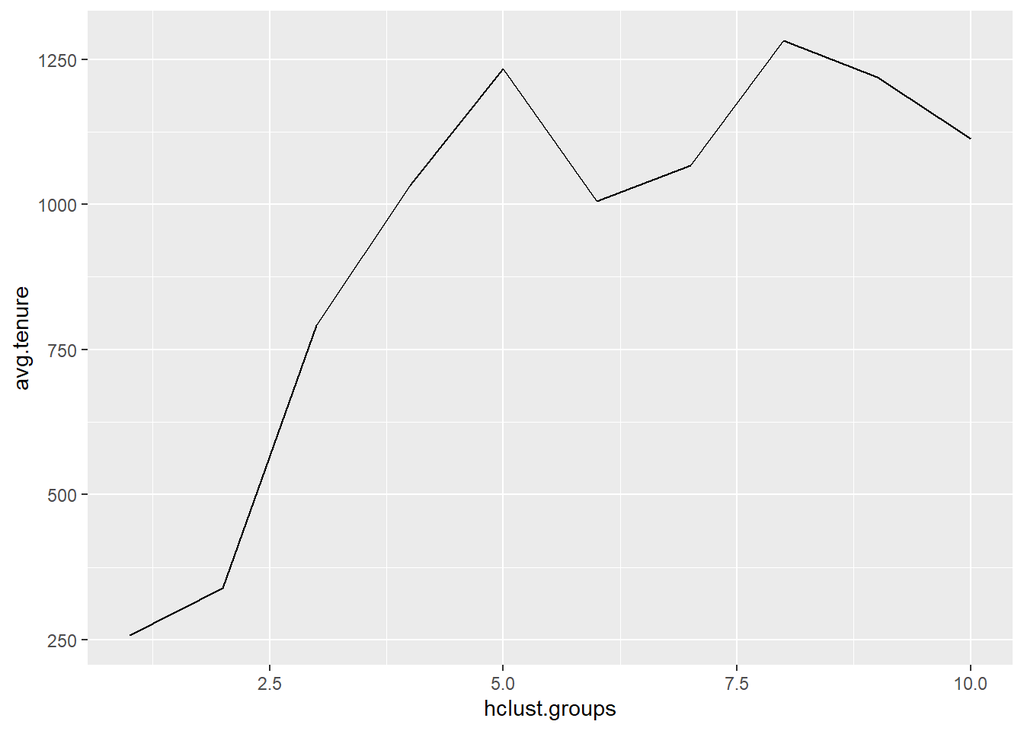

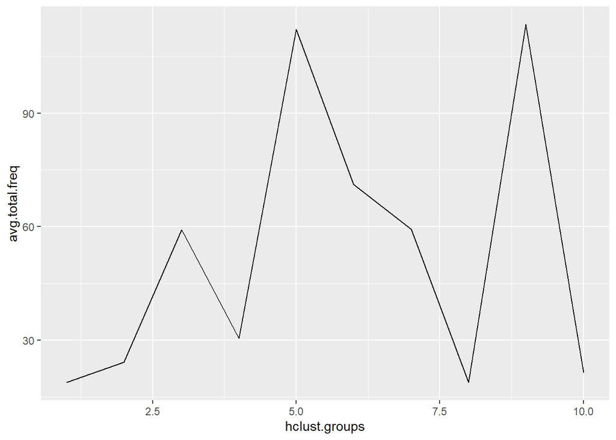

Observation: There are groups with distinct features emerging from the analysis but some groups maybe sparsely populated

```
## # A tibble: 10 x 2
##    hclust.groups     n
##            <int> <int>
##  1             1  1786
##  2             3   720
##  3             2   412
##  4             5   347
##  5             6   155
##  6             7   104
##  7             4    76
##  8            10    33
##  9             8    24
## 10             9    24
```

Obervation: There are six groups with more than 100 observations; top 3 groups cover ~80% and top 4 cover ~90% of the ids

### 4.2.2 Mean Shift

```
## # A tibble: 79 x 2
##    ms.groups     n
##        <dbl> <int>
##  1         1  2367
##  2         2   588
##  3         5   174
##  4         3    93
##  5         8    73
##  6        10    67
##  7        14    44
##  8        18    41
##  9        20    34
## 10        16    29
## # ... with 69 more rows
```

Observation: Top 3 groups contain ~85% of the ids

### 4.2.3 K-means clustering and selection of K

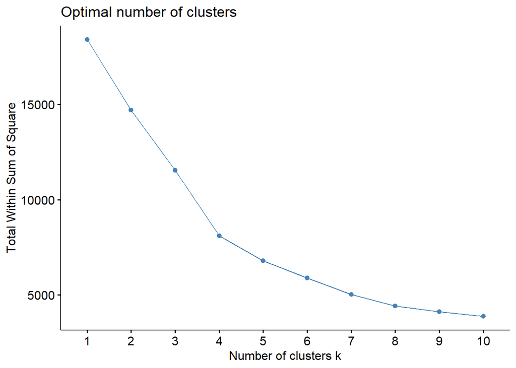

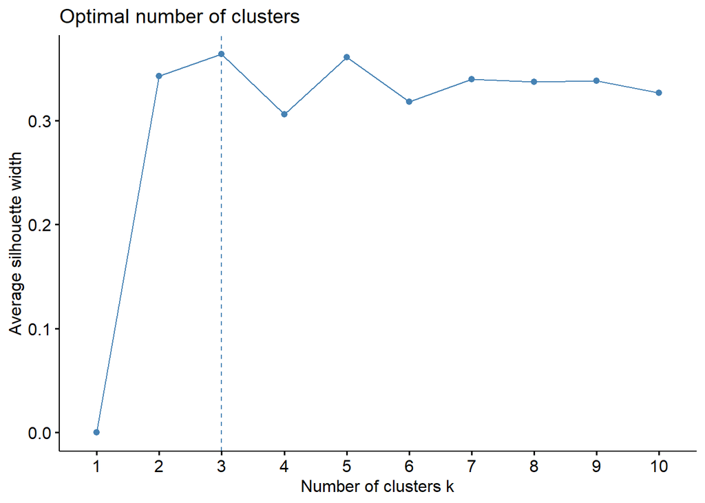

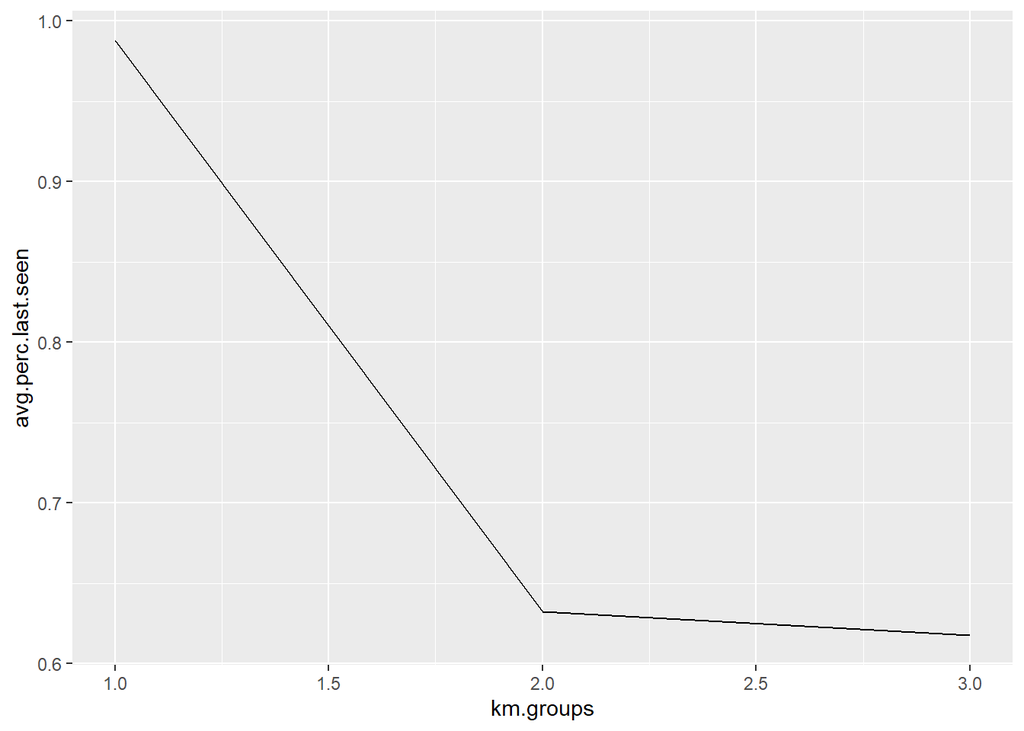

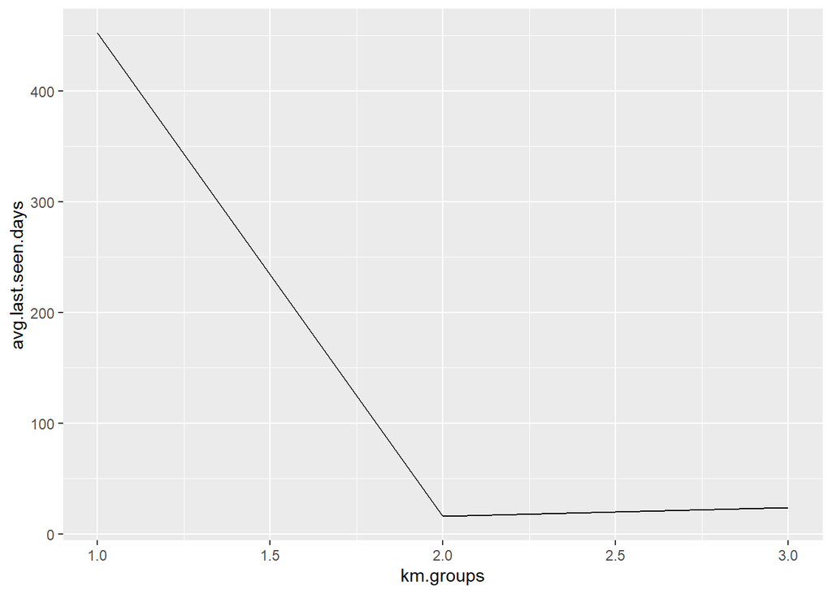

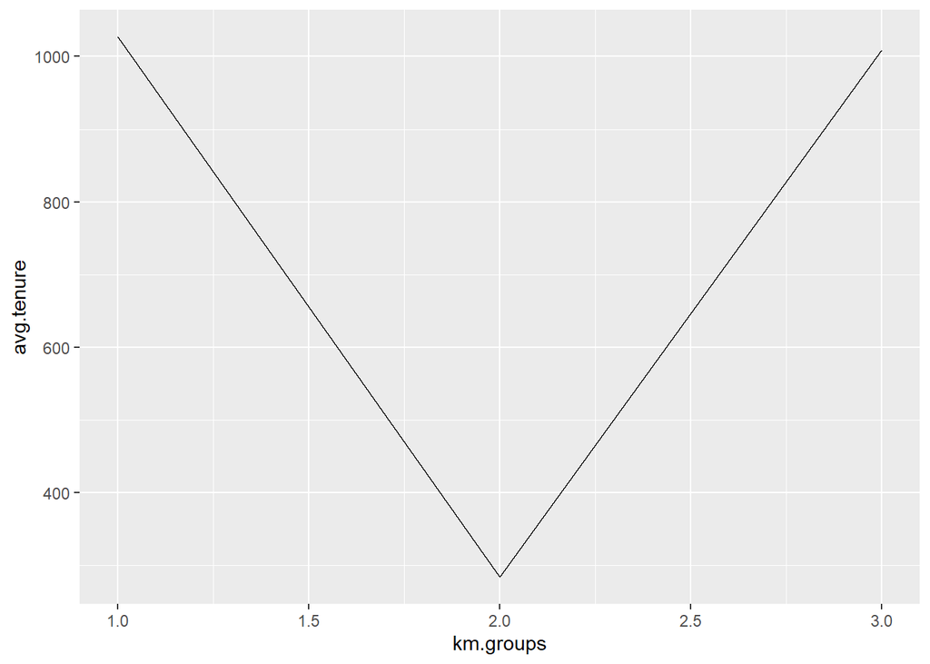

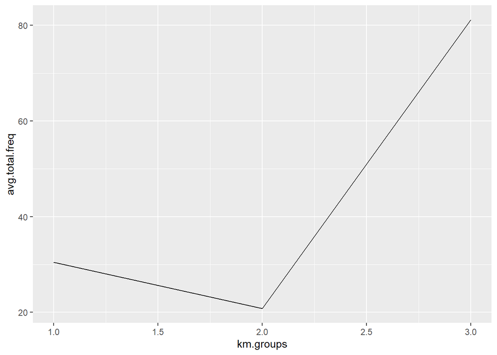

## 4.3 Key Findings

- Results from Hierarchical Clustering, Meanshift, and K-means clusters suggests that there are 3 major clusters in the data
- Variables used for clustering:
  1. Percentile last seen: Percentile of Last seen days in the distribution of inter-arrival time of the customer
  2. Last seen days: Number of days from last activity till end of observation period
  3. Tenure: Number of days the ID was on the system in the observation period
  4. Total Freq: Number of activities in the observation peroid